# A Survey on Technology Choice

The assigned variable for me is: PG5_7NDYP, which is the number of developers in a project. I need to decide a hypothesis, and generate a model to validate my model.

```r
# For nicer printing
options(digits=2);
```

```r
# Read in the data
data <- read.csv("TechSurvey - Survey.csv",header=T);

#convert date to unix second
for (i in c("Start", "End"))
    data[,i] = as.numeric(as.POSIXct(strptime(data[,i], "%Y-%m-%d %H:%M:%S")))
for (i in 0:12){
    vnam = paste(c("PG",i,"Submit"), collapse="")
    data[,vnam] = as.numeric(as.POSIXct(strptime(data[,vnam], "%Y-%m-%d %H:%M:%S")))
}
#calculate differences in time
for (i in 12:0){
    pv = paste(c("PG",i-1,"Submit"), collapse="");
    if (i==0)
        pv="Start";
    vnam = paste(c("PG",i,"Submit"), collapse="");
    data[,vnam] = data[,vnam] -data[,pv];
}
```

# Interpret basic summaries

```r
#now explore variables
summary(data);
```

```
     Device    Completed       Start               End               PG0Dis
        :  2   0    :  2   Min.   :1.54e+09   Min.   :1.54e+09   Min.   :  0
 Bot    :  1   FALSE:546   1st Qu.:1.54e+09   1st Qu.:1.54e+09   1st Qu.:  0
 PC     :955   TRUE :805   Median :1.54e+09   Median :1.54e+09   Median :  1
 Phone  :376               Mean   :1.54e+09   Mean   :1.54e+09   Mean   : 44
 Tablet : 16               3rd Qu.:1.54e+09   3rd Qu.:1.54e+09   3rd Qu.: 24
 Unknown:  3               Max.   :1.54e+09   Max.   :1.54e+09   Max.   :168
                           NA's   :2          NA's   :548        NA's   :73
    PG0Shown      PG0Submit                                     PG1PsnUse
 Min.   :   0   Min.   :    2   For personal work and/or research use:727
 1st Qu.:   0   1st Qu.:    6                                        :613
 Median : 102   Median :    9   Chapter book                         :  1
 Mean   : 249   Mean   :  299   dissertation research                :  1
 3rd Qu.: 428   3rd Qu.:   15   for teaching                         :  1
 Max.   :1190   Max.   :76226   for teaching undergraduate statistics:  1
 NA's   :73     NA's   :199     (Other)                              :  9
                                                                        PG1WdAuth
                                                                             :1145
 Because Microsoft was paying me to do it                                    :   1
 For a wider audience, such as developers of other packages or other software: 205
 Hackathon                                                                   :   1
 Tool for other researchers to analyse their data                            :   1


                                PG1Trn
                                   :1168
 For a training / class that I took: 184
 teaching economics                :   1




                                                               PG1Other
                                                                   :1272
 Other                                                             :  23
 teaching                                                          :   3
 Teaching                                                          :   3
 For training that I gave                                          :   2
 How does software technology spreads in the open source community?:   2
 (Other)                                                           :  48
```

[output cut: 161 more lines]

```
 Min.   :   1                       :576   Min.   :  1              :590
 1st Qu.:   5   Female              : 96   1st Qu.:  4   18 - 24    : 34
 Median :   7   Male                :652   Median :  4   25 - 34    :338
 Mean   :  17   Prefer not to answer: 29   Mean   :  6   35 - 44    :258
 3rd Qu.:  11                              3rd Qu.:  5   45 - 54    : 89
 Max.   :5966                              Max.   :605   55 - 64    : 36
 NA's   :546                               NA's   :548   65 and over:  8
   PG12Submit
 Min.   :   1
 1st Qu.:   4
 Median :   5
 Mean   :   8
 3rd Qu.:   6
 Max.   :1566
 NA's   :548
```

```r
#get numeric fields only for correlation
sel = c()
for (i in 1:dim(data)[2]) if (is.numeric(data[,i])) sel = c(sel, i);


cor(data[,sel],method="spearman",use="pairwise.complete.obs"); #OK for any: uses ranks
```

|  | Start | End | PG0Dis | PG0Shown | PG0Submit | PG1Submit | PG2Submit | PG3Submit | PG4Dtr0_6 | PG4Psv7_8 | ⋯ | PG5_12Order | PG5_13Order | PG5Submit | PG6Submit | PG7Submit | PG8Submit | PG9Submit | PG10Submit | PG11Submit | PG12Submit |
| --- | --- | --- | --- | --- | --- | --- | --- | --- | --- | --- | --- | --- | --- | --- | --- | --- | --- | --- | --- | --- | --- |
| Start | 1.0000 | 0.9952 | -0.0417 | -0.11507 | 0.1350 | 0.1156 | 0.0791 | 0.0384 | 0.01210 | 0.00371 | ⋯ | -0.0369 | 0.0598 | 0.08512 | 0.0054 | 0.0776 | 0.0441 | 0.04101 | 0.047 | 7.9e-02 | 0.0746 |
| End | 0.9952 | 1.0000 | -0.0415 | -0.09879 | 0.1142 | 0.1550 | 0.0791 | 0.0511 | -0.05185 | -0.04576 | ⋯ | -0.0359 | 0.0661 | 0.09088 | 0.0051 | 0.0759 | 0.0435 | 0.04071 | 0.052 | 7.9e-02 | 0.0772 |
| PG0Dis | -0.0417 | -0.0415 | 1.0000 | 0.87220 | 0.0153 | 0.0065 | 0.0041 | 0.0567 | 0.16368 | 0.02668 | ⋯ | 0.0151 | 0.0384 | 0.00601 | 0.0277 | 0.0097 | 0.0354 | 0.00995 | -0.029 | -4.5e-02 | 0.0546 |
| PG0Shown | -0.1151 | -0.0988 | 0.8722 | 1.00000 | 0.0360 | 0.0205 | 0.0023 | 0.0497 | 0.08226 | 0.00036 | ⋯ | 0.0074 | 0.0407 | -0.00888 | 0.0401 | 0.0121 | 0.0264 | 0.00056 | -0.045 | -7.1e-02 | 0.0436 |
| PG0Submit | 0.1350 | 0.1142 | 0.0153 | 0.03596 | 1.0000 | 0.1088 | 0.1037 | 0.1273 | -0.00802 | -0.03763 | ⋯ | -0.0161 | -0.0280 | 0.17671 | 0.1518 | 0.1365 | 0.1258 | 0.17579 | 0.225 | 1.1e-01 | 0.1096 |
| PG1Submit | 0.1156 | 0.1550 | 0.0065 | 0.02047 | 0.1088 | 1.0000 | 0.1452 | 0.2688 | -0.06852 | 0.05661 | ⋯ | 0.0512 | -0.0651 | 0.24670 | 0.2414 | 0.1133 | 0.1069 | 0.10895 | 0.170 | 7.4e-02 | 0.1137 |
| PG2Submit | 0.0791 | 0.0791 | 0.0041 | 0.00235 | 0.1037 | 0.1452 | 1.0000 | 0.2045 | 0.00146 | 0.00897 | ⋯ | 0.0210 | -0.0047 | 0.21851 | 0.2696 | 0.1245 | 0.1567 | 0.20127 | 0.099 | 1.1e-01 | 0.1073 |
| PG3Submit | 0.0384 | 0.0511 | 0.0567 | 0.04968 | 0.1273 | 0.2688 | 0.2045 | 1.0000 | 0.00865 | 0.04424 | ⋯ | 0.0464 | -0.0222 | 0.26048 | 0.2706 | 0.1316 | 0.1822 | 0.27450 | 0.161 | 1.4e-01 | 0.1642 |
| PG4Dtr0_6 | 0.0121 | -0.0518 | 0.1637 | 0.08226 | -0.0080 | -0.0685 | 0.0015 | 0.0087 | 1.00000 | NA | ⋯ | 0.1774 | -0.1289 | -0.05214 | -0.1618 | 0.1560 | 0.0695 | -0.07292 | 0.044 | 8.4e-04 | -0.0272 |
| PG4Psv7_8 | 0.0037 | -0.0458 | 0.0267 | 0.00036 | -0.0376 | 0.0566 | 0.0090 | 0.0442 | NA | 1.00000 | ⋯ | -0.0008 | -0.0218 | 0.08974 | -0.0146 | -0.0363 | 0.0526 | 0.05977 | 0.069 | -4.9e-02 | -0.0217 |
| PG4Prm9_10 | -0.0267 | -0.0267 | -0.0092 | 0.03279 | -0.0939 | 0.0120 | -0.0587 | -0.0062 | NA | NA | ⋯ | 0.0233 | 0.0916 | 0.00077 | -0.0418 | -0.0633 | -0.0550 | -0.02989 | -0.061 | -8.6e-05 | 0.0169 |
| PG4AllResp | 0.0063 | -0.0158 | 0.0018 | -0.02094 | -0.0236 | 0.0297 | 0.0293 | -0.0193 | 1.00000 | 1.00000 | ⋯ | -0.0306 | -0.0166 | 0.01248 | -0.0040 | -0.0753 | -0.1294 | -0.03812 | -0.106 | -8.2e-02 | -0.0668 |
| PG4Submit | 0.0187 | 0.0172 | -0.0539 | -0.05978 | 0.2191 | 0.1651 | 0.1515 | 0.1956 | -0.14272 | -0.08350 | ⋯ | -0.0119 | -0.0376 | 0.27328 | 0.3326 | 0.2775 | 0.1821 | 0.33236 | 0.391 | 2.8e-01 | 0.2360 |
| PG5_1Order | 0.0218 | 0.0196 | 0.0140 | 0.01254 | -0.0240 | 0.0750 | -0.0069 | 0.0578 | -0.09488 | -0.01399 | ⋯ | -0.0785 | -0.0950 | 0.08054 | 0.0334 | 0.0173 | -0.0388 | 0.01033 | -0.096 | -2.5e-02 | 0.0238 |
| PG5_2Order | 0.0014 | 0.0002 | -0.0386 | -0.03617 | 0.0402 | -0.0226 | -0.0297 | 0.0048 | -0.00954 | 0.08081 | ⋯ | 0.0527 | -0.0652 | 0.03898 | -0.0571 | -0.0551 | -0.0567 | -0.01925 | 0.015 | 7.3e-03 | 0.0469 |
| PG5_3Order | -0.0089 | -0.0177 | 0.0441 | 0.04228 | 0.0155 | 0.0391 | -0.0131 | 0.0172 | 0.13631 | 0.04396 | ⋯ | -0.0698 | -0.0250 | 0.23450 | 0.0419 | 0.0058 | -0.0086 | 0.02604 | 0.063 | 3.4e-02 | 0.0538 |
| PG5_4Order | 0.0931 | 0.0949 | -0.0262 | -0.02214 | -0.0172 | 0.0293 | 0.0560 | -0.0462 | 0.01735 | -0.12489 | ⋯ | -0.0447 | -0.0329 | 0.14487 | 0.0414 | 0.0460 | 0.0182 | -0.03734 | -0.075 | -8.6e-02 | -0.0211 |
| PG5_5Order | -0.0523 | -0.0466 | -0.0087 | -0.01058 | 0.0860 | 0.0345 | 0.0570 | -0.0165 | 0.04533 | -0.06369 | ⋯ | -0.0499 | -0.0981 | 0.28698 | 0.0498 | 0.0372 | 0.0427 | -0.02976 | 0.076 | 2.4e-02 | 0.0085 |
| PG5_6Order | 0.0237 | 0.0217 | -0.0480 | -0.04902 | 0.0762 | 0.0327 | 0.1077 | 0.0370 | -0.13255 | 0.01662 | ⋯ | -0.0430 | -0.0031 | 0.22759 | 0.0165 | 0.0222 | 0.0639 | -0.02974 | 0.015 | 2.8e-02 | 0.0539 |
| PG5_7Order | -0.0200 | -0.0236 | 0.0220 | -0.00444 | -0.1174 | -0.0815 | -0.0285 | 0.0242 | -0.16196 | -0.06938 | ⋯ | 0.0410 | 0.0944 | 0.06439 | -0.0222 | -0.1082 | -0.0804 | -0.01762 | -0.017 | -4.4e-02 | -0.0617 |
| PG5_8Order | -0.0804 | -0.0852 | -0.0147 | -0.00433 | -0.0421 | -0.0205 | -0.0387 | -0.0129 | -0.16181 | 0.01019 | ⋯ | -0.0896 | -0.1168 | 0.13787 | -0.1227 | -0.0126 | -0.0526 | -0.05699 | -0.065 | -3.7e-02 | -0.0182 |
| PG5_9Order | 0.0171 | 0.0167 | -0.0712 | -0.10235 | 0.0476 | 0.0260 | -0.0410 | -0.0641 | -0.07948 | -0.09747 | ⋯ | -0.0431 | -0.0837 | 0.18534 | -0.0188 | -0.0314 | -0.0898 | -0.01354 | -0.034 | 6.2e-03 | -0.0280 |
| PG5_10Order | -0.0214 | -0.0112 | 0.0200 | 0.02736 | 0.0086 | -0.0017 | -0.0418 | 0.0581 | -0.05310 | 0.15949 | ⋯ | -0.0905 | -0.1214 | 0.22151 | 0.0427 | 0.0311 | 0.0345 | 0.02011 | 0.102 | 1.8e-02 | -0.0092 |
| PG5_11Order | -0.0241 | -0.0196 | 0.0190 | 0.02551 | 0.0927 | -0.0047 | -0.1043 | 0.0279 | 0.02791 | -0.03487 | ⋯ | 0.1233 | 0.1434 | 0.02942 | -0.0055 | 0.0210 | 0.0232 | 0.05579 | -0.038 | -2.5e-03 | 0.0275 |
| PG5_12Order | -0.0369 | -0.0359 | 0.0151 | 0.00743 | -0.0161 | 0.0512 | 0.0210 | 0.0464 | 0.17741 | -0.00080 | ⋯ | 1.0000 | 0.1231 | 0.10997 | 0.0777 | 0.0529 | 0.0149 | 0.00295 | 0.016 | 2.4e-02 | 0.0167 |
| PG5_13Order | 0.0598 | 0.0661 | 0.0384 | 0.04072 | -0.0280 | -0.0651 | -0.0047 | -0.0222 | -0.12890 | -0.02179 | ⋯ | 0.1231 | 1.0000 | 0.00976 | -0.0209 | 0.0355 | 0.0556 | 0.07229 | -0.023 | 1.3e-02 | -0.0614 |
| PG5Submit | 0.0851 | 0.0909 | 0.0060 | -0.00888 | 0.1767 | 0.2467 | 0.2185 | 0.2605 | -0.05214 | 0.08974 | ⋯ | 0.1100 | 0.0098 | 1.00000 | 0.3224 | 0.2312 | 0.2035 | 0.30291 | 0.269 | 2.4e-01 | 0.2588 |
| PG6Submit | 0.0054 | 0.0051 | 0.0277 | 0.04005 | 0.1518 | 0.2414 | 0.2696 | 0.2706 | -0.16179 | -0.01463 | ⋯ | 0.0777 | -0.0209 | 0.32240 | 1.0000 | 0.3086 | 0.2065 | 0.44528 | 0.343 | 2.8e-01 | 0.2904 |
| PG7Submit | 0.0776 | 0.0759 | 0.0097 | 0.01212 | 0.1365 | 0.1133 | 0.1245 | 0.1316 | 0.15596 | -0.03631 | ⋯ | 0.0529 | 0.0355 | 0.23120 | 0.3086 | 1.0000 | 0.1606 | 0.27819 | 0.312 | 2.8e-01 | 0.2523 |
| PG8Submit | 0.0441 | 0.0435 | 0.0354 | 0.02635 | 0.1258 | 0.1069 | 0.1567 | 0.1822 | 0.06953 | 0.05260 | ⋯ | 0.0149 | 0.0556 | 0.20351 | 0.2065 | 0.1606 | 1.0000 | 0.25569 | 0.200 | 2.1e-01 | 0.1932 |
| PG9Submit | 0.0410 | 0.0407 | 0.0099 | 0.00056 | 0.1758 | 0.1090 | 0.2013 | 0.2745 | -0.07292 | 0.05977 | ⋯ | 0.0029 | 0.0723 | 0.30291 | 0.4453 | 0.2782 | 0.2557 | 1.00000 | 0.290 | 2.8e-01 | 0.2755 |
| PG10Submit | 0.0474 | 0.0517 | -0.0293 | -0.04481 | 0.2248 | 0.1701 | 0.0989 | 0.1614 | 0.04433 | 0.06942 | ⋯ | 0.0159 | -0.0227 | 0.26881 | 0.3428 | 0.3121 | 0.2000 | 0.29018 | 1.000 | 3.5e-01 | 0.3131 |
| PG11Submit | 0.0790 | 0.0792 | -0.0454 | -0.07102 | 0.1093 | 0.0738 | 0.1147 | 0.1383 | 0.00084 | -0.04870 | ⋯ | 0.0240 | 0.0130 | 0.23552 | 0.2777 | 0.2768 | 0.2065 | 0.27906 | 0.346 | 1.0e+00 | 0.2513 |
| PG12Submit | 0.0746 | 0.0772 | 0.0546 | 0.04364 | 0.1096 | 0.1137 | 0.1073 | 0.1642 | -0.02721 | -0.02169 | ⋯ | 0.0167 | -0.0614 | 0.25876 | 0.2904 | 0.2523 | 0.1932 | 0.27550 | 0.313 | 2.5e-01 | 1.0000 |

```r
library(dplyr)
library(tidyr)
library(caret)
library(randomForest)
```

```r
data_complete = filter(data, Completed == TRUE)

# Number of rows removed
print(nrow(data))
print(nrow(data_complete))
```

```
[1] 1353
[1] 805
```

# Sample Question-1: Time to take the Survey

```r
# Calculate Total time to finish the Survey
survey_time = data_complete$End - data_complete$Start
print("Servey Time in seconds:")
print(paste0("Max:", max(survey_time)))
print(paste0("Min: ", min(survey_time)))
print(paste0("Average: ", round(mean(survey_time))))
print(paste0("Median: ", median(survey_time)))
```

```
[1] "Servey Time in seconds:"
[1] "Max:87551"
[1] "Min: 51"
[1] "Average: 680"
[1] "Median: 225"
```

# Sample Question- 2, 3: Question which takes longest or least time?

```r
# Select only completion times and remove a couple na
completion_time = select(data_complete, contains('Submit')) %>%
    na.omit()
print(summary(completion_time))
```

```
   PG0Submit       PG1Submit      PG2Submit      PG3Submit      PG4Submit
 Min.   :    2   Min.   :   1   Min.   :   1   Min.   :   1   Min.   :  1
 1st Qu.:    6   1st Qu.:  11   1st Qu.:   9   1st Qu.:  16   1st Qu.:  6
 Median :   10   Median :  16   Median :  13   Median :  24   Median :  7
 Mean   :  242   Mean   :  42   Mean   :  31   Mean   :  42   Mean   :  9
 3rd Qu.:   15   3rd Qu.:  31   3rd Qu.:  31   3rd Qu.:  41   3rd Qu.:  9
 Max.   :66474   Max.   :6892   Max.   :1470   Max.   :4648   Max.   :332
   PG5Submit      PG6Submit      PG7Submit     PG8Submit     PG9Submit
 Min.   :   3   Min.   :   1   Min.   :  1   Min.   :  1   Min.   :    0
 1st Qu.:  45   1st Qu.:   7   1st Qu.:  6   1st Qu.:  5   1st Qu.:    7
 Median :  62   Median :   9   Median :  8   Median :  8   Median :   10
 Mean   :  85   Mean   :  25   Mean   : 11   Mean   : 12   Mean   :   40
 3rd Qu.:  84   3rd Qu.:  12   3rd Qu.: 11   3rd Qu.: 14   3rd Qu.:   14
 Max.   :4130   Max.   :5759   Max.   :777   Max.   :207   Max.   :20126
   PG10Submit     PG11Submit    PG12Submit
 Min.   :   1   Min.   :  1   Min.   :   1
 1st Qu.:   5   1st Qu.:  4   1st Qu.:   4
 Median :   7   Median :  4   Median :   5
 Mean   :  17   Mean   :  6   Mean   :   8
 3rd Qu.:  10   3rd Qu.:  5   3rd Qu.:   6
 Max.   :5966   Max.   :605   Max.   :1566
```

```r
avg_completion_time = colMeans(completion_time)
med_completion_time = apply(completion_time, 2, FUN = median)
print('Average Completion Time for each question')
print(avg_completion_time)
print('Median Completion Time for each question')
print(med_completion_time)
```

```
[1] "Average Completion Time for each question"
 PG0Submit  PG1Submit  PG2Submit  PG3Submit  PG4Submit  PG5Submit  PG6Submit
     241.5       42.4       31.4       42.5        9.1       85.2       24.5
 PG7Submit  PG8Submit  PG9Submit PG10Submit PG11Submit PG12Submit
      10.6       11.6       39.9       16.7        6.4        7.8
[1] "Median Completion Time for each question"
 PG0Submit  PG1Submit  PG2Submit  PG3Submit  PG4Submit  PG5Submit  PG6Submit
        10         16         13         24          7         62          9
 PG7Submit  PG8Submit  PG9Submit PG10Submit PG11Submit PG12Submit
         8          8         10          7          4          5
```

<font color = 'blue'>Question which takes longest time to finish: PG0 = 241.5;</font> <font color = 'blue'>Qurstion which takes least time to finish: PG11 = 6.4</font>

# Sample Question-4: Top-ranked criteria

```r
# Select only completion times and remove a couple na
crit_responses = select(data_complete, starts_with('PG5'), -ends_with('Time'), -ends_with('Order'), -ends_with('Submit'))
print(summary(crit_responses))
```

```
           PG5_1RRPQ             PG5_2BNUI              PG5_3HDS
                :335                  :381                  :225
 Essential      : 59   Essential      :  3   Essential      :103
 High Priority  :102   High Priority  : 25   High Priority  :199
 Low Priority   : 85   Low Priority   :120   Low Priority   : 68
 Medium Priority:130   Medium Priority: 91   Medium Priority:161
 Not a Priority : 94   Not a Priority :185   Not a Priority : 49
            PG5_4VGP              PG5_5PHR             PG5_6SSYOP
                :311                  :213                  :310
 Essential      : 22   Essential      : 79   Essential      : 61
 High Priority  :109   High Priority  :247   High Priority  :136
 Low Priority   : 87   Low Priority   : 63   Low Priority   : 83
 Medium Priority:162   Medium Priority:160   Medium Priority:109
 Not a Priority :114   Not a Priority : 43   Not a Priority :106
           PG5_7NDYP              PG5_8CP               PG5_9FRP
                :392                  :174                  :197
 Essential      :  8   Essential      :228   Essential      :165
 High Priority  : 31   High Priority  :195   High Priority  :241
 Low Priority   : 90   Low Priority   : 51   Low Priority   : 40
 Medium Priority: 52   Medium Priority:121   Medium Priority:123
 Not a Priority :232   Not a Priority : 36   Not a Priority : 39
           PG5_10RPA             PG5_11NSG             PG5_12NWG
                :239                  :349                  :373
 Essential      : 54   Essential      :  6   High Priority  : 10
 High Priority  :200   High Priority  : 28   Low Priority   : 76
 Low Priority   : 79   Low Priority   : 87   Medium Priority: 25
 Medium Priority:150   Medium Priority: 68   Not a Priority :321
 Not a Priority : 83   Not a Priority :267
           PG5_13NFG
                :377
 High Priority  : 10
 Low Priority   : 75
 Medium Priority: 37
 Not a Priority :306
```

<font color = 'blue'>We can see PG5_8CP has the highest essential value = 228, which is Computing Performance. So, it should be the answer for top-ranked criteria. </font>

# Sample Question-5: Demographic distribution by Age

```
    18 - 24     25 - 34     35 - 44     45 - 54     55 - 64 65 and over
         34         338         258          89          36           8
```

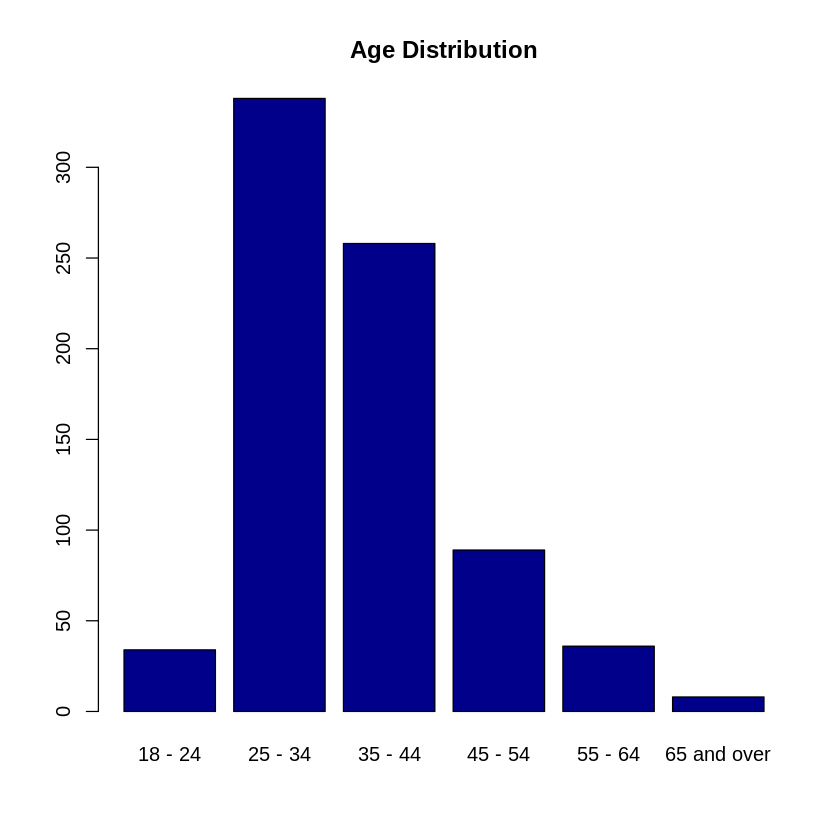

```r
age = select(data_complete, PG12Resp) %>%
    filter(PG12Resp != '')

age1 = factor(age[,])

print(summary(age1))
barplot(table(age1), main = 'Age Distribution', col='darkblue')
```

# Hypothesis

<font color = 'blue'>My response variable is: Number of developers in your project, which is PG5_NDYP. I believe, the priority is going to be affected by the following factors-

Mostly, PG1PsnUse -- For personal work and/or research use.  
And also by,  
**PG6Resp -- Development Experience,**  
**PG9Resp -- Number of software projects involved in** </font>

```r
print('Print the column names')
colnames(data_complete)
```

```
[1] "Print the column names"
```

1. 'Device'

2. 'Completed'

3. 'Start'

4. 'End'

5. 'PG0Dis'

6. 'PG0Shown'

7. 'PG0Submit'

8. 'PG1PsnUse'

9. 'PG1WdAuth'

10. 'PG1Trn'

11. 'PG1Other'

12. 'PG1Submit'

13. 'PG2Resp'

14. 'PG2Submit'

15. 'PG2Resp.1'

16. 'PG3Submit'

17. 'PG4Dtr0_6'

18. 'PG4Psv7_8'

19. 'PG4Prm9_10'

20. 'PG4AllResp'

21. 'PG4Submit'

22. 'PG5_1RRPQ'

23. 'PG5_1Order'

24. 'PG5_1Time'

25. 'PG5_2BNUI'

26. 'PG5_2Order'

27. 'PG5_2Time'

28. 'PG5_3HDS'

29. 'PG5_3Order'

30. 'PG5_3Time'

31. 'PG5_4VGP'

32. 'PG5_4Order'

33. 'PG5_4Time'

34. 'PG5_5PHR'

35. 'PG5_5Order'

36. 'PG5_5Time'

37. 'PG5_6SSYOP'

38. 'PG5_6Order'

39. 'PG5_6Time'

40. 'PG5_7NDYP'

41. 'PG5_7Order'

42. 'PG5_7Time'

43. 'PG5_8CP'

44. 'PG5_8Order'

45. 'PG5_8Time'

46. 'PG5_9FRP'

47. 'PG5_9Order'

48. 'PG5_9Time'

49. 'PG5_10RPA'

50. 'PG5_10Order'

51. 'PG5_10Time'

52. 'PG5_11NSG'

53. 'PG5_11Order'

54. 'PG5_11Time'

55. 'PG5_12NWG'

56. 'PG5_12Order'

57. 'PG5_12Time'

58. 'PG5_13NFG'

59. 'PG5_13Order'

60. 'PG5_13Time'

61. 'PG5Submit'

62. 'PG6Resp'

63. 'PG6Submit'

64. 'PG7R'

65. 'PG7C.C..'

66. 'PG7Java'

67. 'PG7Python'

68. 'PG7Javascript'

69. 'PG7Go'

70. 'PG7C.'

71. 'PG7Other'

72. 'PG7Submit'

73. 'PG8Resp'

74. 'PG8Submit'

75. 'PG9Resp'

76. 'PG9Submit'

77. 'PG10Resp'

78. 'PG10Submit'

79. 'PG11Resp'

80. 'PG11Submit'

81. 'PG12Resp'

82. 'PG12Submit'

# Transformation and Cleaning

<font color = 'blue'> We need to handle the missing values, and categoriacal data. Missing values are always thread to get better results. Here I replaced the missing values with the column mean to get better result. I'm not sure whether its a good idea.</font>

```r
for (i in 1:dim(data)[2]) if (is.factor(data[,i])) data[,i] = as.numeric(data[,i]);

#Replacing missing with mean value
for (i in 1:ncol(data)){
    data[is.na(data[,i]),i] = mean (data[,i],na.rm =TRUE)
}
head (data)
```

| Device | Completed | Start | End | PG0Dis | PG0Shown | PG0Submit | PG1PsnUse | PG1WdAuth | PG1Trn | ⋯ | PG8Resp | PG8Submit | PG9Resp | PG9Submit | PG10Resp | PG10Submit | PG11Resp | PG11Submit | PG12Resp | PG12Submit |
| --- | --- | --- | --- | --- | --- | --- | --- | --- | --- | --- | --- | --- | --- | --- | --- | --- | --- | --- | --- | --- |
| 3 | 2 | 1.5e+09 | 1.5e+09 | 44 | 249 | 299 | 1 | 1 | 1 | ⋯ | 1 | 12 | 1 | 40 | 1 | 17 | 1 | 6.4 | 1 | 7.8 |
| 3 | 2 | 1.5e+09 | 1.5e+09 | 44 | 249 | 299 | 1 | 1 | 1 | ⋯ | 1 | 12 | 1 | 40 | 1 | 17 | 1 | 6.4 | 1 | 7.8 |
| 3 | 3 | 1.5e+09 | 1.5e+09 | 44 | 249 | 6 | 4 | 1 | 1 | ⋯ | 183 | 12 | 3 | 5 | 2 | 6 | 3 | 3.0 | 5 | 4.0 |
| 3 | 2 | 1.5e+09 | 1.5e+09 | 44 | 249 | 25 | 4 | 1 | 1 | ⋯ | 1 | 12 | 1 | 40 | 1 | 17 | 1 | 6.4 | 1 | 7.8 |
| 3 | 3 | 1.5e+09 | 1.5e+09 | 44 | 249 | 8 | 4 | 1 | 1 | ⋯ | 199 | 19 | 6 | 13 | 2 | 6 | 3 | 4.0 | 6 | 5.0 |
| 3 | 2 | 1.5e+09 | 1.5e+09 | 44 | 249 | 2 | 1 | 1 | 1 | ⋯ | 1 | 12 | 1 | 40 | 1 | 17 | 1 | 6.4 | 1 | 7.8 |

# Correlation Analysis

To find the relationships among data columns we need to analyze the the correlation.

```r
sel = c()
for (i in 1:dim(data)[2]) if (is.numeric(data[,i])) sel = c(sel, i);

d =data[,sel]

cor(d,method="spearman",use="pairwise.complete.obs");
```

|  | Device | Completed | Start | End | PG0Dis | PG0Shown | PG0Submit | PG1PsnUse | PG1WdAuth | PG1Trn | ⋯ | PG8Resp | PG8Submit | PG9Resp | PG9Submit | PG10Resp | PG10Submit | PG11Resp | PG11Submit | PG12Resp | PG12Submit |
| --- | --- | --- | --- | --- | --- | --- | --- | --- | --- | --- | --- | --- | --- | --- | --- | --- | --- | --- | --- | --- | --- |
| Device | 1.0000 | -0.1039 | -0.08252 | -0.008 | 0.0058 | 0.0020 | 0.0381 | -0.039 | -0.0586 | 0.0169 | ⋯ | -0.1070 | 0.0161 | -0.0887 | 0.13153 | -0.0770 | 0.1349 | -0.1059 | 0.058 | -1.1e-01 | 0.115 |
| Completed | -0.1039 | 1.0000 | -0.03539 | -0.443 | -0.0155 | 0.0120 | -0.2515 | 0.395 | 0.1398 | 0.1665 | ⋯ | 0.8598 | -0.2677 | 0.8601 | -0.82428 | 0.8783 | -0.7599 | 0.9081 | -0.667 | 8.5e-01 | -0.685 |
| Start | -0.0825 | -0.0354 | 1.00000 | 0.656 | -0.1211 | -0.1468 | 0.1774 | -0.063 | -0.0940 | 0.0381 | ⋯ | -0.0155 | 0.0236 | -0.0147 | 0.04866 | -0.0318 | 0.0542 | -0.0392 | 0.068 | -9.9e-03 | 0.049 |
| End | -0.0080 | -0.4425 | 0.65555 | 1.000 | -0.0663 | -0.1390 | 0.1608 | -0.183 | -0.1426 | -0.0136 | ⋯ | -0.3748 | 0.1258 | -0.3626 | 0.38233 | -0.3797 | 0.3702 | -0.4103 | 0.343 | -3.5e-01 | 0.318 |
| PG0Dis | 0.0058 | -0.0155 | -0.12114 | -0.066 | 1.0000 | 0.8539 | -0.0285 | 0.051 | -0.0061 | -0.0256 | ⋯ | -0.0149 | 0.0474 | -0.0070 | -0.00026 | 0.0028 | -0.0075 | -0.0196 | -0.038 | -1.5e-02 | 0.028 |
| PG0Shown | 0.0020 | 0.0120 | -0.14682 | -0.139 | 0.8539 | 1.0000 | -0.0181 | 0.071 | 0.0167 | -0.0332 | ⋯ | 0.0059 | 0.0350 | 0.0207 | -0.02597 | 0.0128 | -0.0319 | 0.0082 | -0.061 | 6.0e-06 | 0.012 |
| PG0Submit | 0.0381 | -0.2515 | 0.17742 | 0.161 | -0.0285 | -0.0181 | 1.0000 | -0.282 | -0.1000 | -0.0463 | ⋯ | -0.1930 | 0.1453 | -0.2432 | 0.26746 | -0.1672 | 0.2950 | -0.2405 | 0.216 | -2.3e-01 | 0.222 |
| PG1PsnUse | -0.0386 | 0.3954 | -0.06305 | -0.183 | 0.0511 | 0.0712 | -0.2824 | 1.000 | -0.0490 | -0.1746 | ⋯ | 0.3164 | -0.1271 | 0.3364 | -0.33924 | 0.3555 | -0.2801 | 0.3816 | -0.293 | 3.1e-01 | -0.289 |
| PG1WdAuth | -0.0586 | 0.1398 | -0.09401 | -0.143 | -0.0061 | 0.0167 | -0.1000 | -0.049 | 1.0000 | -0.0922 | ⋯ | 0.1162 | -0.0824 | 0.1430 | -0.14512 | 0.1137 | -0.1147 | 0.1552 | -0.093 | 1.5e-01 | -0.058 |
| PG1Trn | 0.0169 | 0.1665 | 0.03807 | -0.014 | -0.0256 | -0.0332 | -0.0463 | -0.175 | -0.0922 | 1.0000 | ⋯ | 0.2170 | 0.0398 | 0.1444 | -0.10679 | 0.1813 | -0.0592 | 0.1352 | -0.047 | 1.6e-01 | -0.069 |
| PG1Other | 0.0160 | 0.0989 | 0.02446 | 0.030 | -0.0162 | -0.0165 | -0.0715 | -0.167 | -0.0454 | -0.0809 | ⋯ | 0.0881 | -0.0316 | 0.0953 | -0.06391 | 0.0589 | -0.1034 | 0.0698 | -0.068 | 1.1e-01 | -0.066 |
| PG1Submit | -0.0187 | -0.2322 | 0.15061 | 0.206 | -0.0139 | -0.0149 | 0.2741 | -0.270 | -0.0054 | -0.1190 | ⋯ | -0.1911 | 0.1240 | -0.2140 | 0.22404 | -0.1727 | 0.2539 | -0.2064 | 0.202 | -1.6e-01 | 0.202 |
| PG2Resp | -0.1011 | 0.6310 | -0.04378 | -0.256 | 0.0118 | 0.0280 | -0.2612 | 0.361 | 0.0922 | 0.2294 | ⋯ | 0.5619 | -0.1487 | 0.5647 | -0.53885 | 0.5339 | -0.4945 | 0.5906 | -0.419 | 5.4e-01 | -0.411 |
| PG2Submit | -0.0828 | -0.2122 | 0.09302 | 0.140 | 0.0023 | -0.0120 | 0.2007 | -0.211 | 0.0263 | -0.1562 | ⋯ | -0.1819 | 0.1647 | -0.1951 | 0.26736 | -0.1786 | 0.2054 | -0.1916 | 0.199 | -1.8e-01 | 0.179 |
| PG2Resp.1 | -0.0813 | 0.7297 | -0.05482 | -0.314 | 0.0254 | 0.0412 | -0.2557 | 0.390 | 0.1189 | 0.1390 | ⋯ | 0.6349 | -0.2106 | 0.6566 | -0.60038 | 0.6560 | -0.5578 | 0.6794 | -0.472 | 6.4e-01 | -0.480 |
| PG3Submit | 0.0768 | -0.3616 | 0.05900 | 0.200 | 0.0508 | 0.0318 | 0.2105 | -0.195 | -0.0453 | -0.1092 | ⋯ | -0.3140 | 0.2382 | -0.3284 | 0.41935 | -0.2909 | 0.3673 | -0.3088 | 0.324 | -3.1e-01 | 0.336 |
| PG4Dtr0_6 | 0.0149 | 0.0511 | 0.01515 | -0.018 | 0.0476 | 0.0364 | -0.0338 | 0.011 | 0.0049 | 0.1043 | ⋯ | 0.0547 | -0.0018 | 0.0338 | -0.05689 | 0.0502 | -0.0436 | 0.0608 | -0.046 | 4.6e-02 | -0.042 |
| PG4Psv7_8 | -0.0340 | 0.1126 | -0.00561 | -0.070 | 0.0068 | -0.0018 | -0.0443 | 0.048 | 0.0550 | 0.0375 | ⋯ | 0.0575 | 0.0156 | 0.1205 | -0.06544 | 0.1298 | -0.0371 | 0.1228 | -0.074 | 1.0e-01 | -0.064 |
| PG4Prm9_10 | -0.0466 | 0.3269 | -0.03036 | -0.176 | -0.0092 | 0.0158 | -0.1248 | 0.171 | 0.0390 | -0.0386 | ⋯ | 0.2534 | -0.1827 | 0.3061 | -0.29255 | 0.2445 | -0.2967 | 0.3009 | -0.246 | 2.8e-01 | -0.251 |
| PG4AllResp | -0.0617 | 0.1727 | -0.00035 | -0.086 | 0.0027 | -0.0138 | -0.0414 | 0.072 | 0.0580 | -0.1023 | ⋯ | 0.0879 | -0.1525 | 0.1702 | -0.15380 | 0.1061 | -0.2029 | 0.1477 | -0.181 | 1.4e-01 | -0.164 |
| PG4Submit | 0.1182 | -0.3796 | 0.02374 | 0.159 | -0.0229 | -0.0363 | 0.2491 | -0.193 | -0.0738 | -0.0213 | ⋯ | -0.2961 | 0.2374 | -0.3587 | 0.46200 | -0.2109 | 0.5026 | -0.3305 | 0.414 | -3.3e-01 | 0.392 |
| PG5_1RRPQ | -0.0774 | 0.5703 | -0.07509 | -0.313 | 0.0182 | 0.0263 | -0.1225 | 0.232 | 0.1013 | 0.0575 | ⋯ | 0.4926 | -0.1507 | 0.4910 | -0.47177 | 0.4857 | -0.4510 | 0.5148 | -0.389 | 4.7e-01 | -0.393 |
| PG5_1Order | 0.0248 | -0.0031 | 0.01706 | 0.021 | -0.0133 | -0.0139 | -0.0054 | -0.021 | 0.0586 | -0.0041 | ⋯ | -0.0088 | -0.0501 | 0.0072 | -0.02554 | -0.0445 | -0.0428 | 0.0205 | -0.026 | 3.7e-03 | 0.021 |
| PG5_1Time | -0.0978 | 0.5710 | 0.07463 | -0.148 | -0.0012 | 0.0108 | -0.1021 | 0.229 | 0.0892 | 0.0893 | ⋯ | 0.5051 | -0.1434 | 0.4999 | -0.46661 | 0.4944 | -0.4206 | 0.5064 | -0.376 | 4.7e-01 | -0.382 |
| PG5_2BNUI | -0.0790 | 0.5319 | -0.05777 | -0.264 | 0.0202 | 0.0190 | -0.1474 | 0.196 | 0.1118 | 0.0713 | ⋯ | 0.4669 | -0.1542 | 0.4512 | -0.46165 | 0.4503 | -0.4347 | 0.4907 | -0.372 | 4.4e-01 | -0.380 |
| PG5_2Order | -0.0484 | -0.0217 | 0.01276 | 0.020 | -0.0528 | -0.0429 | 0.0211 | -0.039 | -0.0133 | -0.0407 | ⋯ | -0.0262 | -0.0095 | -0.0042 | 0.03460 | -0.0268 | 0.0395 | -0.0435 | 0.021 | -2.4e-02 | 0.051 |
| PG5_2Time | -0.0884 | 0.5305 | 0.06967 | -0.124 | 0.0038 | 0.0032 | -0.1291 | 0.203 | 0.0976 | 0.0905 | ⋯ | 0.4673 | -0.1541 | 0.4636 | -0.45483 | 0.4548 | -0.4161 | 0.4807 | -0.363 | 4.4e-01 | -0.368 |
| PG5_3HDS | -0.0852 | 0.6683 | -0.00072 | -0.262 | 0.0015 | -0.0009 | -0.1569 | 0.266 | 0.1434 | 0.0821 | ⋯ | 0.5636 | -0.1533 | 0.5821 | -0.53357 | 0.5809 | -0.5109 | 0.6211 | -0.442 | 5.8e-01 | -0.435 |
| PG5_3Order | 0.0674 | -0.1042 | -0.02315 | 0.027 | 0.0371 | 0.0329 | 0.0216 | -0.066 | 0.0613 | -0.0488 | ⋯ | -0.0669 | 0.0119 | -0.1026 | 0.07491 | -0.0664 | 0.0944 | -0.0695 | 0.070 | -1.3e-01 | 0.072 |
| PG5_3Time | -0.1190 | 0.6687 | 0.19838 | -0.039 | -0.0310 | -0.0392 | -0.1452 | 0.279 | 0.1034 | 0.0978 | ⋯ | 0.5749 | -0.1654 | 0.5923 | -0.54147 | 0.5706 | -0.5187 | 0.6051 | -0.458 | 5.8e-01 | -0.443 |
| ⋮ | ⋮ | ⋮ | ⋮ | ⋮ | ⋮ | ⋮ | ⋮ | ⋮ | ⋮ | ⋮ | ⋱ | ⋮ | ⋮ | ⋮ | ⋮ | ⋮ | ⋮ | ⋮ | ⋮ | ⋮ | ⋮ |
| PG5_11Order | -0.01224 | -0.0056 | -0.0067 | -0.0155 | 0.01309 | 1.8e-02 | 0.0515 | -0.0620 | -0.0076 | 0.0668 | ⋯ | -0.017 | 0.03226 | -0.0321 | 0.0100 | -0.0223 | 0.0037 | -0.0049 | 0.0162 | 0.00059 | 0.032 |
| PG5_11Time | -0.09529 | 0.5562 | 0.1026 | -0.1077 | -0.02351 | -1.6e-02 | -0.1229 | 0.2342 | 0.1072 | 0.0669 | ⋯ | 0.487 | -0.16441 | 0.4932 | -0.4804 | 0.4916 | -0.4156 | 0.4930 | -0.3795 | 0.46089 | -0.387 |
| PG5_12NWG | -0.08187 | 0.5452 | -0.0414 | -0.2522 | 0.01412 | 1.7e-02 | -0.1271 | 0.2194 | 0.1391 | 0.0462 | ⋯ | 0.477 | -0.15863 | 0.4717 | -0.4711 | 0.4744 | -0.4323 | 0.4860 | -0.3812 | 0.44638 | -0.389 |
| PG5_12Order | -0.00078 | -0.0141 | -0.0215 | -0.0053 | 0.02609 | 1.6e-02 | -0.0067 | -0.0351 | 0.0362 | 0.0170 | ⋯ | -0.025 | -0.00045 | -0.0134 | 0.0089 | -0.0197 | 0.0155 | 0.0028 | 0.0190 | 0.00834 | 0.013 |
| PG5_12Time | -0.09014 | 0.5399 | 0.0821 | -0.1156 | -0.00298 | 2.9e-03 | -0.1087 | 0.2204 | 0.1218 | 0.0686 | ⋯ | 0.472 | -0.15960 | 0.4766 | -0.4633 | 0.4718 | -0.4119 | 0.4811 | -0.3669 | 0.44154 | -0.375 |
| PG5_13NFG | -0.08880 | 0.5408 | -0.0484 | -0.2645 | 0.00462 | 3.8e-03 | -0.1359 | 0.2161 | 0.1285 | 0.0437 | ⋯ | 0.469 | -0.15225 | 0.4620 | -0.4871 | 0.4642 | -0.4406 | 0.4886 | -0.3665 | 0.44950 | -0.372 |
| PG5_13Order | 0.03348 | 0.0292 | 0.0155 | 0.0097 | 0.02307 | 2.9e-02 | -0.0251 | -0.0077 | 0.0019 | 0.0047 | ⋯ | 0.039 | 0.02614 | 0.0093 | -0.0113 | -0.0015 | -0.0402 | 0.0315 | 0.0024 | 0.02025 | -0.045 |
| PG5_13Time | -0.09679 | 0.5364 | 0.0757 | -0.1294 | -0.00890 | -3.8e-03 | -0.1129 | 0.2191 | 0.1165 | 0.0672 | ⋯ | 0.464 | -0.15833 | 0.4674 | -0.4771 | 0.4645 | -0.4132 | 0.4799 | -0.3584 | 0.44849 | -0.364 |
| PG5Submit | 0.00772 | -0.4777 | 0.0743 | 0.2782 | -0.00097 | -1.4e-02 | 0.2256 | -0.2027 | -0.0163 | -0.0785 | ⋯ | -0.395 | 0.30992 | -0.4378 | 0.5488 | -0.3590 | 0.5399 | -0.4332 | 0.4804 | -0.38041 | 0.477 |
| PG6Resp | -0.07782 | 0.8754 | -0.0195 | -0.3747 | 0.01114 | 2.0e-02 | -0.1987 | 0.3451 | 0.0818 | 0.1957 | ⋯ | 0.775 | -0.19852 | 0.7325 | -0.7193 | 0.7836 | -0.6400 | 0.7888 | -0.5986 | 0.74173 | -0.577 |
| PG6Submit | 0.10351 | -0.7775 | 0.0301 | 0.3410 | 0.02013 | 1.0e-02 | 0.2515 | -0.3049 | -0.0820 | -0.1431 | ⋯ | -0.669 | 0.31572 | -0.6703 | 0.7687 | -0.6331 | 0.7137 | -0.6992 | 0.6307 | -0.62333 | 0.628 |
| PG7R | -0.06617 | 0.8714 | -0.0365 | -0.3975 | -0.00842 | 1.4e-02 | -0.2342 | 0.3809 | 0.1452 | 0.0847 | ⋯ | 0.746 | -0.26368 | 0.7632 | -0.7476 | 0.7657 | -0.6867 | 0.8036 | -0.6043 | 0.74525 | -0.612 |
| PG7C.C.. | -0.03730 | 0.2135 | -0.0053 | -0.0902 | -0.03385 | -3.5e-02 | -0.0781 | 0.1037 | 0.1004 | 0.0569 | ⋯ | 0.214 | -0.02654 | 0.2284 | -0.1616 | 0.1960 | -0.1250 | 0.2238 | -0.0587 | 0.21290 | -0.148 |
| PG7Java | -0.05692 | 0.1564 | 0.0162 | -0.0455 | -0.01199 | 8.3e-03 | -0.0170 | 0.0613 | 0.0197 | 0.1126 | ⋯ | 0.165 | -0.01197 | 0.1819 | -0.1214 | 0.1858 | -0.0640 | 0.1646 | -0.1007 | 0.15667 | -0.107 |
| PG7Python | -0.00621 | 0.3633 | -0.0278 | -0.1741 | 0.02746 | 5.1e-02 | -0.0619 | 0.1236 | 0.0307 | 0.1525 | ⋯ | 0.332 | -0.12569 | 0.3448 | -0.3149 | 0.3485 | -0.2316 | 0.3430 | -0.2630 | 0.29041 | -0.244 |
| PG7Javascript | -0.00125 | 0.1518 | -0.0241 | -0.1027 | -0.00544 | 1.4e-02 | -0.0605 | 0.0314 | 0.0050 | 0.0723 | ⋯ | 0.190 | -0.04460 | 0.1431 | -0.1230 | 0.1397 | -0.1146 | 0.1487 | -0.0978 | 0.13298 | -0.116 |
| PG7Go | 0.01701 | 0.0317 | -0.0164 | -0.0380 | 0.01948 | 3.2e-02 | 0.0335 | 0.0343 | -0.0164 | -0.0153 | ⋯ | 0.016 | -0.05163 | 0.0122 | -0.0190 | 0.0464 | 0.0010 | 0.0147 | -0.0083 | 0.02766 | -0.010 |
| PG7C. | -0.03413 | 0.1084 | 0.0273 | -0.0259 | -0.00039 | 9.1e-03 | -0.0201 | -0.0014 | 0.0414 | 0.0973 | ⋯ | 0.161 | -0.04294 | 0.1165 | -0.0772 | 0.1165 | -0.0292 | 0.1136 | 0.0103 | 0.11964 | -0.024 |
| PG7Other | -0.06906 | 0.1858 | 0.0453 | -0.0268 | -0.00929 | -1.7e-02 | -0.0384 | 0.0896 | 0.0031 | 0.1012 | ⋯ | 0.185 | -0.01887 | 0.1514 | -0.1283 | 0.1725 | -0.1536 | 0.1650 | -0.0841 | 0.20384 | -0.075 |
| PG7Submit | 0.06967 | -0.4066 | 0.0599 | 0.2109 | 0.01585 | 2.6e-04 | 0.1766 | -0.1862 | -0.0623 | 0.1065 | ⋯ | -0.314 | 0.25029 | -0.3393 | 0.4538 | -0.2822 | 0.4681 | -0.3345 | 0.4434 | -0.28951 | 0.401 |
| PG8Resp | -0.10695 | 0.8598 | -0.0155 | -0.3748 | -0.01494 | 5.9e-03 | -0.1930 | 0.3164 | 0.1162 | 0.2170 | ⋯ | 1.000 | -0.06055 | 0.7417 | -0.7080 | 0.7733 | -0.6259 | 0.8050 | -0.5368 | 0.73671 | -0.568 |
| PG8Submit | 0.01608 | -0.2677 | 0.0236 | 0.1258 | 0.04738 | 3.5e-02 | 0.1453 | -0.1271 | -0.0824 | 0.0398 | ⋯ | -0.061 | 1.00000 | -0.2859 | 0.3628 | -0.1970 | 0.3196 | -0.2313 | 0.3005 | -0.21000 | 0.272 |
| PG9Resp | -0.08870 | 0.8601 | -0.0147 | -0.3626 | -0.00695 | 2.1e-02 | -0.2432 | 0.3364 | 0.1430 | 0.1444 | ⋯ | 0.742 | -0.28591 | 1.0000 | -0.7111 | 0.7419 | -0.6789 | 0.8093 | -0.5801 | 0.77013 | -0.580 |
| PG9Submit | 0.13153 | -0.8243 | 0.0487 | 0.3823 | -0.00026 | -2.6e-02 | 0.2675 | -0.3392 | -0.1451 | -0.1068 | ⋯ | -0.708 | 0.36281 | -0.7111 | 1.0000 | -0.6864 | 0.7278 | -0.7546 | 0.6525 | -0.70902 | 0.658 |
| PG10Resp | -0.07704 | 0.8783 | -0.0318 | -0.3797 | 0.00279 | 1.3e-02 | -0.1672 | 0.3555 | 0.1137 | 0.1813 | ⋯ | 0.773 | -0.19703 | 0.7419 | -0.6864 | 1.0000 | -0.4664 | 0.8124 | -0.5407 | 0.73225 | -0.553 |
| PG10Submit | 0.13487 | -0.7599 | 0.0542 | 0.3702 | -0.00753 | -3.2e-02 | 0.2950 | -0.2801 | -0.1147 | -0.0592 | ⋯ | -0.626 | 0.31963 | -0.6789 | 0.7278 | -0.4664 | 1.0000 | -0.6746 | 0.6729 | -0.64688 | 0.656 |
| PG11Resp | -0.10588 | 0.9081 | -0.0392 | -0.4103 | -0.01959 | 8.2e-03 | -0.2405 | 0.3816 | 0.1552 | 0.1352 | ⋯ | 0.805 | -0.23131 | 0.8093 | -0.7546 | 0.8124 | -0.6746 | 1.0000 | -0.5488 | 0.79697 | -0.607 |
| PG11Submit | 0.05754 | -0.6666 | 0.0679 | 0.3431 | -0.03798 | -6.1e-02 | 0.2163 | -0.2930 | -0.0928 | -0.0469 | ⋯ | -0.537 | 0.30047 | -0.5801 | 0.6525 | -0.5407 | 0.6729 | -0.5488 | 1.0000 | -0.54546 | 0.586 |
| PG12Resp | -0.11477 | 0.8518 | -0.0099 | -0.3534 | -0.01476 | 6.0e-06 | -0.2330 | 0.3127 | 0.1540 | 0.1555 | ⋯ | 0.737 | -0.21000 | 0.7701 | -0.7090 | 0.7322 | -0.6469 | 0.7970 | -0.5455 | 1.00000 | -0.534 |
| PG12Submit | 0.11545 | -0.6846 | 0.0492 | 0.3177 | 0.02821 | 1.2e-02 | 0.2223 | -0.2889 | -0.0581 | -0.0689 | ⋯ | -0.568 | 0.27191 | -0.5802 | 0.6577 | -0.5535 | 0.6562 | -0.6071 | 0.5862 | -0.53404 | 1.000 |

```r
high_corr <- function(x, level){
  res <- cor(x, method="spearman");
  res1 <- res; res1[res<0] <- -res[res < 0];
  for (i in 1:dim(x)[2]){
    res1[i,i] <- 0;
  }
  sel <- apply(res1,1,max) > level;
  res[sel,sel];
}
high_corr(d,.7)
```

|  | Completed | PG0Dis | PG0Shown | PG2Resp.1 | PG5_1RRPQ | PG5_1Time | PG5_2BNUI | PG5_2Time | PG5_3HDS | PG5_3Time | ⋯ | PG6Resp | PG6Submit | PG7R | PG8Resp | PG9Resp | PG9Submit | PG10Resp | PG10Submit | PG11Resp | PG12Resp |
| --- | --- | --- | --- | --- | --- | --- | --- | --- | --- | --- | --- | --- | --- | --- | --- | --- | --- | --- | --- | --- | --- |
| Completed | 1.000 | -0.01554 | 1.2e-02 | 0.730 | 0.570 | 0.5710 | 0.532 | 0.5305 | 0.6683 | 0.669 | ⋯ | 0.875 | -0.78 | 0.8714 | 0.8598 | 0.860 | -0.82428 | 0.8783 | -0.7599 | 0.9081 | 8.5e-01 |
| PG0Dis | -0.016 | 1.00000 | 8.5e-01 | 0.025 | 0.018 | -0.0012 | 0.020 | 0.0038 | 0.0015 | -0.031 | ⋯ | 0.011 | 0.02 | -0.0084 | -0.0149 | -0.007 | -0.00026 | 0.0028 | -0.0075 | -0.0196 | -1.5e-02 |
| PG0Shown | 0.012 | 0.85391 | 1.0e+00 | 0.041 | 0.026 | 0.0108 | 0.019 | 0.0032 | -0.0009 | -0.039 | ⋯ | 0.020 | 0.01 | 0.0138 | 0.0059 | 0.021 | -0.02597 | 0.0128 | -0.0319 | 0.0082 | 6.0e-06 |
| PG2Resp.1 | 0.730 | 0.02535 | 4.1e-02 | 1.000 | 0.416 | 0.4156 | 0.386 | 0.3857 | 0.4989 | 0.498 | ⋯ | 0.650 | -0.56 | 0.6511 | 0.6349 | 0.657 | -0.60038 | 0.6560 | -0.5578 | 0.6794 | 6.4e-01 |
| PG5_1RRPQ | 0.570 | 0.01820 | 2.6e-02 | 0.416 | 1.000 | 0.9383 | 0.861 | 0.8329 | 0.7069 | 0.656 | ⋯ | 0.513 | -0.44 | 0.5144 | 0.4926 | 0.491 | -0.47177 | 0.4857 | -0.4510 | 0.5148 | 4.7e-01 |
| PG5_1Time | 0.571 | -0.00121 | 1.1e-02 | 0.416 | 0.938 | 1.0000 | 0.820 | 0.8630 | 0.6905 | 0.718 | ⋯ | 0.519 | -0.44 | 0.5131 | 0.5051 | 0.500 | -0.46661 | 0.4944 | -0.4206 | 0.5064 | 4.7e-01 |
| PG5_2BNUI | 0.532 | 0.02023 | 1.9e-02 | 0.386 | 0.861 | 0.8197 | 1.000 | 0.9536 | 0.7047 | 0.656 | ⋯ | 0.482 | -0.42 | 0.4760 | 0.4669 | 0.451 | -0.46165 | 0.4503 | -0.4347 | 0.4907 | 4.4e-01 |
| PG5_2Time | 0.530 | 0.00383 | 3.2e-03 | 0.386 | 0.833 | 0.8630 | 0.954 | 1.0000 | 0.7003 | 0.715 | ⋯ | 0.486 | -0.42 | 0.4758 | 0.4673 | 0.464 | -0.45483 | 0.4548 | -0.4161 | 0.4807 | 4.4e-01 |
| PG5_3HDS | 0.668 | 0.00152 | -9.0e-04 | 0.499 | 0.707 | 0.6905 | 0.705 | 0.7003 | 1.0000 | 0.907 | ⋯ | 0.593 | -0.51 | 0.5910 | 0.5636 | 0.582 | -0.53357 | 0.5809 | -0.5109 | 0.6211 | 5.8e-01 |
| PG5_3Time | 0.669 | -0.03102 | -3.9e-02 | 0.498 | 0.656 | 0.7180 | 0.656 | 0.7153 | 0.9070 | 1.000 | ⋯ | 0.599 | -0.53 | 0.5821 | 0.5749 | 0.592 | -0.54147 | 0.5706 | -0.5187 | 0.6051 | 5.8e-01 |
| PG5_4VGP | 0.591 | 0.01057 | 5.2e-03 | 0.431 | 0.780 | 0.7534 | 0.819 | 0.8063 | 0.6914 | 0.656 | ⋯ | 0.542 | -0.47 | 0.5204 | 0.5118 | 0.512 | -0.51600 | 0.5044 | -0.4712 | 0.5311 | 4.8e-01 |
| PG5_4Time | 0.589 | -0.00507 | -4.8e-03 | 0.430 | 0.734 | 0.7732 | 0.773 | 0.8199 | 0.6754 | 0.716 | ⋯ | 0.535 | -0.45 | 0.5163 | 0.5133 | 0.518 | -0.50526 | 0.5126 | -0.4538 | 0.5242 | 4.8e-01 |
| PG5_5PHR | 0.676 | 0.02487 | 1.9e-02 | 0.522 | 0.693 | 0.6713 | 0.695 | 0.6841 | 0.6783 | 0.656 | ⋯ | 0.612 | -0.52 | 0.6242 | 0.6119 | 0.590 | -0.56407 | 0.5613 | -0.5467 | 0.6245 | 5.6e-01 |
| PG5_5Time | 0.674 | 0.00544 | 9.0e-03 | 0.497 | 0.641 | 0.6945 | 0.646 | 0.7043 | 0.6644 | 0.732 | ⋯ | 0.603 | -0.53 | 0.6205 | 0.5937 | 0.600 | -0.57151 | 0.5416 | -0.5636 | 0.6116 | 5.7e-01 |
| PG5_6SSYOP | 0.595 | 0.02738 | 2.9e-02 | 0.433 | 0.781 | 0.7576 | 0.791 | 0.7778 | 0.6672 | 0.644 | ⋯ | 0.547 | -0.47 | 0.5411 | 0.5305 | 0.518 | -0.49162 | 0.5131 | -0.4700 | 0.5297 | 5.0e-01 |
| PG5_6Time | 0.593 | 0.00437 | 9.2e-03 | 0.430 | 0.730 | 0.7777 | 0.746 | 0.7918 | 0.6485 | 0.701 | ⋯ | 0.547 | -0.47 | 0.5391 | 0.5326 | 0.522 | -0.48532 | 0.5185 | -0.4513 | 0.5209 | 5.0e-01 |
| PG5_7NDYP | 0.524 | 0.02948 | 2.1e-02 | 0.398 | 0.832 | 0.8032 | 0.887 | 0.8657 | 0.6885 | 0.639 | ⋯ | 0.469 | -0.42 | 0.4806 | 0.4674 | 0.451 | -0.45888 | 0.4268 | -0.4377 | 0.4682 | 4.2e-01 |
| PG5_7Time | 0.521 | 0.00745 | 8.2e-03 | 0.389 | 0.812 | 0.8416 | 0.863 | 0.8966 | 0.6772 | 0.690 | ⋯ | 0.466 | -0.42 | 0.4670 | 0.4701 | 0.460 | -0.44776 | 0.4332 | -0.4171 | 0.4635 | 4.2e-01 |
| PG5_8CP | 0.716 | -0.00443 | 8.0e-03 | 0.520 | 0.682 | 0.6629 | 0.675 | 0.6626 | 0.6845 | 0.659 | ⋯ | 0.638 | -0.55 | 0.6273 | 0.6309 | 0.620 | -0.57765 | 0.6334 | -0.5497 | 0.6726 | 6.1e-01 |
| PG5_8Time | 0.712 | -0.03458 | -1.9e-02 | 0.545 | 0.612 | 0.6719 | 0.610 | 0.6697 | 0.6681 | 0.739 | ⋯ | 0.628 | -0.55 | 0.6325 | 0.6243 | 0.625 | -0.56627 | 0.6413 | -0.5182 | 0.6666 | 6.0e-01 |
| PG5_9FRP | 0.689 | 0.01633 | 2.5e-02 | 0.511 | 0.686 | 0.6712 | 0.687 | 0.6807 | 0.6802 | 0.661 | ⋯ | 0.624 | -0.56 | 0.6225 | 0.5970 | 0.607 | -0.58629 | 0.5966 | -0.5376 | 0.6356 | 5.7e-01 |
| PG5_9Time | 0.690 | -0.00408 | 4.5e-03 | 0.480 | 0.633 | 0.6925 | 0.639 | 0.6973 | 0.6609 | 0.740 | ⋯ | 0.626 | -0.56 | 0.6159 | 0.6020 | 0.614 | -0.58283 | 0.5860 | -0.5323 | 0.6235 | 5.8e-01 |
| PG5_10RPA | 0.653 | 0.00713 | -1.7e-03 | 0.476 | 0.696 | 0.6721 | 0.720 | 0.7144 | 0.6953 | 0.682 | ⋯ | 0.598 | -0.51 | 0.5893 | 0.5798 | 0.582 | -0.57108 | 0.5556 | -0.5246 | 0.5937 | 5.6e-01 |
| PG5_10Time | 0.649 | -0.02425 | -3.3e-02 | 0.458 | 0.642 | 0.6874 | 0.669 | 0.7253 | 0.6772 | 0.745 | ⋯ | 0.593 | -0.50 | 0.5922 | 0.5710 | 0.580 | -0.55760 | 0.5382 | -0.5263 | 0.5815 | 5.6e-01 |
| PG5_11NSG | 0.560 | -0.00370 | 2.0e-05 | 0.410 | 0.820 | 0.7929 | 0.876 | 0.8635 | 0.6832 | 0.656 | ⋯ | 0.517 | -0.44 | 0.5179 | 0.4889 | 0.488 | -0.48490 | 0.4833 | -0.4372 | 0.4928 | 4.7e-01 |
| PG5_11Time | 0.556 | -0.02351 | -1.6e-02 | 0.404 | 0.776 | 0.8090 | 0.834 | 0.8814 | 0.6735 | 0.710 | ⋯ | 0.510 | -0.44 | 0.5053 | 0.4873 | 0.493 | -0.48039 | 0.4916 | -0.4156 | 0.4930 | 4.6e-01 |
| PG5_12NWG | 0.545 | 0.01412 | 1.7e-02 | 0.401 | 0.834 | 0.8061 | 0.887 | 0.8796 | 0.7180 | 0.674 | ⋯ | 0.486 | -0.43 | 0.5032 | 0.4766 | 0.472 | -0.47109 | 0.4744 | -0.4323 | 0.4860 | 4.5e-01 |
| PG5_12Time | 0.540 | -0.00298 | 2.9e-03 | 0.392 | 0.807 | 0.8379 | 0.866 | 0.9114 | 0.7060 | 0.724 | ⋯ | 0.485 | -0.42 | 0.4911 | 0.4718 | 0.477 | -0.46329 | 0.4718 | -0.4119 | 0.4811 | 4.4e-01 |
| PG5_13NFG | 0.541 | 0.00462 | 3.8e-03 | 0.388 | 0.844 | 0.8066 | 0.892 | 0.8740 | 0.6928 | 0.653 | ⋯ | 0.488 | -0.42 | 0.4980 | 0.4686 | 0.462 | -0.48710 | 0.4642 | -0.4406 | 0.4886 | 4.5e-01 |
| PG5_13Time | 0.536 | -0.00890 | -3.8e-03 | 0.379 | 0.817 | 0.8438 | 0.869 | 0.9084 | 0.6827 | 0.705 | ⋯ | 0.486 | -0.41 | 0.4851 | 0.4641 | 0.467 | -0.47712 | 0.4645 | -0.4132 | 0.4799 | 4.5e-01 |
| PG6Resp | 0.875 | 0.01114 | 2.0e-02 | 0.650 | 0.513 | 0.5185 | 0.482 | 0.4857 | 0.5929 | 0.599 | ⋯ | 1.000 | -0.71 | 0.7755 | 0.7746 | 0.733 | -0.71933 | 0.7836 | -0.6400 | 0.7888 | 7.4e-01 |
| PG6Submit | -0.777 | 0.02013 | 1.0e-02 | -0.564 | -0.445 | -0.4360 | -0.419 | -0.4163 | -0.5134 | -0.532 | ⋯ | -0.708 | 1.00 | -0.6908 | -0.6688 | -0.670 | 0.76868 | -0.6331 | 0.7137 | -0.6992 | -6.2e-01 |
| PG7R | 0.871 | -0.00842 | 1.4e-02 | 0.651 | 0.514 | 0.5131 | 0.476 | 0.4758 | 0.5910 | 0.582 | ⋯ | 0.775 | -0.69 | 1.0000 | 0.7457 | 0.763 | -0.74757 | 0.7657 | -0.6867 | 0.8036 | 7.5e-01 |
| PG8Resp | 0.860 | -0.01494 | 5.9e-03 | 0.635 | 0.493 | 0.5051 | 0.467 | 0.4673 | 0.5636 | 0.575 | ⋯ | 0.775 | -0.67 | 0.7457 | 1.0000 | 0.742 | -0.70798 | 0.7733 | -0.6259 | 0.8050 | 7.4e-01 |
| PG9Resp | 0.860 | -0.00695 | 2.1e-02 | 0.657 | 0.491 | 0.4999 | 0.451 | 0.4636 | 0.5821 | 0.592 | ⋯ | 0.733 | -0.67 | 0.7632 | 0.7417 | 1.000 | -0.71107 | 0.7419 | -0.6789 | 0.8093 | 7.7e-01 |
| PG9Submit | -0.824 | -0.00026 | -2.6e-02 | -0.600 | -0.472 | -0.4666 | -0.462 | -0.4548 | -0.5336 | -0.541 | ⋯ | -0.719 | 0.77 | -0.7476 | -0.7080 | -0.711 | 1.00000 | -0.6864 | 0.7278 | -0.7546 | -7.1e-01 |
| PG10Resp | 0.878 | 0.00279 | 1.3e-02 | 0.656 | 0.486 | 0.4944 | 0.450 | 0.4548 | 0.5809 | 0.571 | ⋯ | 0.784 | -0.63 | 0.7657 | 0.7733 | 0.742 | -0.68640 | 1.0000 | -0.4664 | 0.8124 | 7.3e-01 |
| PG10Submit | -0.760 | -0.00753 | -3.2e-02 | -0.558 | -0.451 | -0.4206 | -0.435 | -0.4161 | -0.5109 | -0.519 | ⋯ | -0.640 | 0.71 | -0.6867 | -0.6259 | -0.679 | 0.72781 | -0.4664 | 1.0000 | -0.6746 | -6.5e-01 |
| PG11Resp | 0.908 | -0.01959 | 8.2e-03 | 0.679 | 0.515 | 0.5064 | 0.491 | 0.4807 | 0.6211 | 0.605 | ⋯ | 0.789 | -0.70 | 0.8036 | 0.8050 | 0.809 | -0.75464 | 0.8124 | -0.6746 | 1.0000 | 8.0e-01 |
| PG12Resp | 0.852 | -0.01476 | 6.0e-06 | 0.640 | 0.468 | 0.4692 | 0.440 | 0.4415 | 0.5785 | 0.577 | ⋯ | 0.742 | -0.62 | 0.7453 | 0.7367 | 0.770 | -0.70902 | 0.7322 | -0.6469 | 0.7970 | 1.0e+00 |

# Normalizing and removing highly corellated data

There are some variables which seem to be overly correlated. To get a better approximation these variables need to be removed from the dataset.

```r
normFunc <- function(x){(x-mean(x, na.rm = T))/sd(x, na.rm = T)}
d[ , names(d) != "PG5_7NDYP"] <- apply(d[ , names(d) != "PG5_7NDYP"], 2, normFunc)
```

```r
d[c("Completed","Start", "End","PG5_1RRPQ","PG5_2BNUI","PG5_3HDS","PG5_4VGP","PG5_5PHR","PG5_6SSYOP","PG5_9FRP","PG5_8CP",
           "PG5_10RPA","PG5_11NSG","PG5_12NWG","PG5_13NFG", "PG5_2Order", "PG5_2Time","PG5_3Order", "PG5_5Order", "PG5_5Time",
           "PG5_8Time", "PG5_10Order", "PG5_10Time", "PG5_12Order", "PG5_1Order","PG5_1Time", "PG5_3Time", "PG5_4Order",
           "PG5_4Time", "PG5_6Order", "PG5_6Time", "PG5_7Order", "PG5_7Time", "PG5_8Order","PG5_11Order",
           "PG5_11Time", "PG5_12Time", "PG5_13Order", "PG5_13Time" )] <- list(NULL)
```

# Fitting the Statistical Model- Regression Model

```r
res <- c();
vnam <- names(d);
for (i in 2:dim(d)[2]){
  fmla <- as.formula(paste(vnam[i],paste(vnam[-c(1,i)],collapse="+"),sep="~"));
  res <- rbind(res,c(i,round(summary(lm(fmla,data=d))$r.squared,2)));
}
row.names(res) <- vnam[res[,1]];
res[order(-res[,2]),]
```

| PG11Resp | 40 | 0.81 |
| --- | --- | --- |
| PG7R | 25 | 0.76 |
| PG9Resp | 36 | 0.68 |
| PG12Resp | 42 | 0.67 |
| PG6Resp | 23 | 0.60 |
| PG8Resp | 34 | 0.52 |
| PG2Resp | 10 | 0.46 |
| PG10Resp | 38 | 0.46 |
| PG0Dis | 2 | 0.44 |
| PG0Shown | 3 | 0.44 |
| PG5_7NDYP | 19 | 0.43 |
| PG5_9Time | 21 | 0.43 |
| PG2Resp.1 | 12 | 0.42 |
| PG8Submit | 35 | 0.33 |
| PG9Submit | 37 | 0.29 |
| PG1PsnUse | 5 | 0.28 |
| PG4AllResp | 17 | 0.24 |
| PG1Trn | 7 | 0.23 |
| PG7Python | 28 | 0.21 |
| PG4Dtr0_6 | 14 | 0.19 |
| PG5_9Order | 20 | 0.17 |
| PG7Other | 32 | 0.15 |
| PG7C.C.. | 26 | 0.14 |
| PG1WdAuth | 6 | 0.11 |
| PG7Java | 27 | 0.11 |
| PG7C. | 31 | 0.11 |
| PG7Submit | 33 | 0.10 |
| PG7Javascript | 29 | 0.09 |
| PG2Submit | 11 | 0.08 |
| PG10Submit | 39 | 0.08 |
| PG4Submit | 18 | 0.07 |
| PG4Prm9_10 | 16 | 0.06 |
| PG1Other | 8 | 0.05 |
| PG3Submit | 13 | 0.05 |
| PG4Psv7_8 | 15 | 0.05 |
| PG0Submit | 4 | 0.03 |
| PG1Submit | 9 | 0.03 |
| PG6Submit | 24 | 0.03 |
| PG7Go | 30 | 0.03 |
| PG5Submit | 22 | 0.02 |
| PG11Submit | 41 | 0.02 |
| PG12Submit | 43 | 0.02 |

```r
model <- lm(PG5_7NDYP ~ ., data = d)

options(scipen=4)  #Set scipen = 0 to get back to default
summary(model)
```

```
Call:
lm(formula = PG5_7NDYP ~ ., data = d)

Residuals:
   Min     1Q Median     3Q    Max
-4.770 -1.025 -0.053  0.325  4.984

Coefficients:
               Estimate Std. Error t value  Pr(>|t|)
(Intercept)    2.280118   0.041913   54.40   < 2e-16 ***
Device        -0.003131   0.042932   -0.07   0.94187
PG0Dis         0.087115   0.055949    1.56   0.11970
PG0Shown      -0.036897   0.055948   -0.66   0.50970
PG0Submit     -0.114603   0.042557   -2.69   0.00717 **
PG1PsnUse     -0.037782   0.049305   -0.77   0.44365
PG1WdAuth      0.159076   0.044143    3.60   0.00033 ***
PG1Trn        -0.102212   0.047896   -2.13   0.03302 *
PG1Other      -0.034415   0.042956   -0.80   0.42318
PG1Submit     -0.057114   0.042563   -1.34   0.17987
PG2Resp        0.050311   0.056910    0.88   0.37683
PG2Submit     -0.041100   0.043882   -0.94   0.34914
PG2Resp.1      0.036587   0.055154    0.66   0.50722
PG3Submit      0.061938   0.042884    1.44   0.14889
PG4Dtr0_6     -0.028321   0.046539   -0.61   0.54293
PG4Psv7_8     -0.005914   0.043128   -0.14   0.89095
PG4Prm9_10     0.002300   0.043287    0.05   0.95763
PG4AllResp     0.069024   0.047993    1.44   0.15061
PG4Submit     -0.011812   0.043576   -0.27   0.78639
PG5_9Order     0.569513   0.043232   13.17   < 2e-16 ***
PG5_9Time      0.672799   0.052497   12.82   < 2e-16 ***
PG5Submit      0.013982   0.042457    0.33   0.74196
PG6Resp        0.090969   0.066064    1.38   0.16875
PG6Submit     -0.077975   0.042667   -1.83   0.06785 .
PG7R           0.410462   0.085012    4.83 0.0000015 ***
PG7C.C..      -0.006323   0.045188   -0.14   0.88874
PG7Java       -0.046466   0.044562   -1.04   0.29727
PG7Python      0.025824   0.047301    0.55   0.58520
PG7Javascript -0.000833   0.043976   -0.02   0.98490
PG7Go          0.101895   0.042537    2.40   0.01674 *
PG7C.          0.002911   0.044566    0.07   0.94794
PG7Other       0.033898   0.045487    0.75   0.45627
PG7Submit      0.036464   0.044090    0.83   0.40837
PG8Resp        0.126600   0.060476    2.09   0.03651 *
PG8Submit      0.051059   0.051324    0.99   0.32000
PG9Resp        0.033655   0.073685    0.46   0.64793
PG9Submit     -0.132897   0.049672   -2.68   0.00755 **
PG10Resp      -0.098041   0.057009   -1.72   0.08572 .
PG10Submit    -0.024294   0.043644   -0.56   0.57787
PG11Resp       0.144570   0.097001    1.49   0.13636
PG11Submit    -0.026146   0.042403   -0.62   0.53760
PG12Resp      -0.094242   0.073584   -1.28   0.20051
PG12Submit    -0.030106   0.042347   -0.71   0.47725
---
Signif. codes:  0 ‘***’ 0.001 ‘**’ 0.01 ‘*’ 0.05 ‘.’ 0.1 ‘ ’ 1

Residual standard error: 1.5 on 1310 degrees of freedom
Multiple R-squared:  0.43,	Adjusted R-squared:  0.411
F-statistic: 23.5 on 42 and 1310 DF,  p-value: <2e-16
```

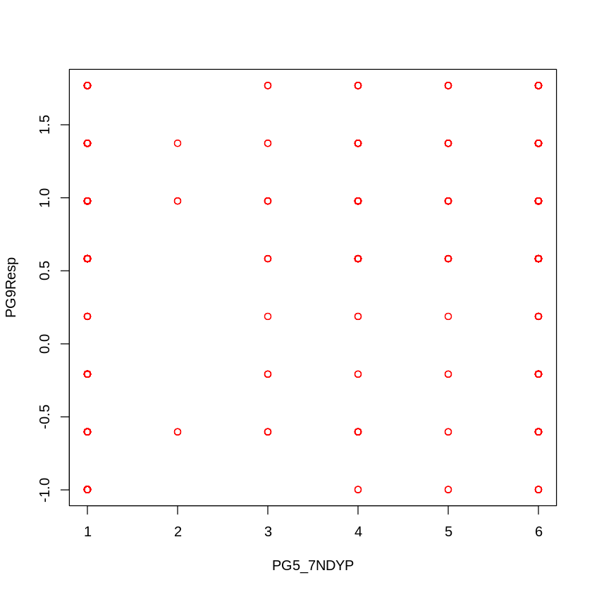

```r
with(d,plot(PG5_7NDYP, PG9Resp, col="red"))
abline(model)
```

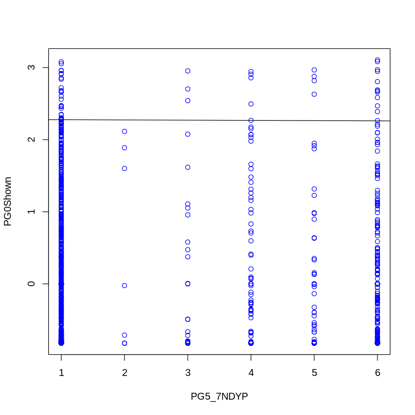

```r
with(d,plot(PG5_7NDYP, PG0Shown, col="blue"))
abline(model)
```

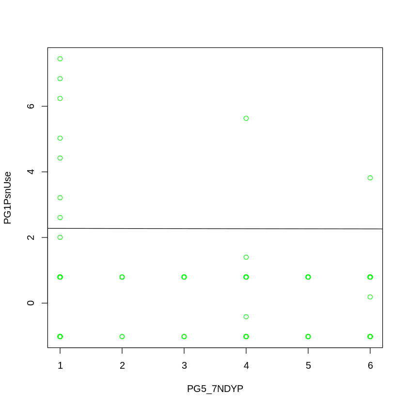

```r
with(d,plot(PG5_7NDYP, PG1PsnUse, col="green"))
abline(model)
```

# Descriptive Analysis and Interpretation of Coefficients

# Extra Credit: Survey Improvement Opportunities

I believe, changing the structure of the survey questions, we can improve the results. Say, for question no 5, we can come for flat multiple choice options. Though I'm not sure, giving a scale of numeric values might improve the results as well.